# gClinBiomarker Package Overivew

#### 4.4.2.3 Subgroup analysis

```
## entries with missing outcome.var are removed! 524 entries left
```

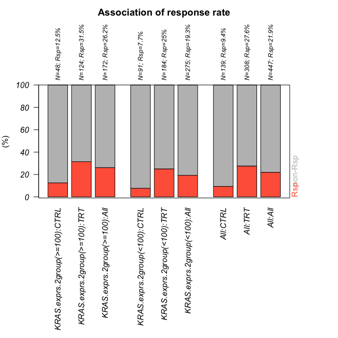

```r
input$KRAS.exprs.2group <- ifelse(input$KRAS.exprs >= 100, ">=100","<100")
input$KRAS.exprs.2group <- factor(input$KRAS.exprs.2group, levels=c(">=100","<100")) # ">=100" as Dx+
Rsp.out.2 <- PlotRspBar(data=input, outcome.var="Response", binary=TRUE,
rsp.response = c("CR","PR"),
rsp.nonresponse = c("SD", "PD","NON CR/PD","NE"),trt="Arm",
 bep = "BEP",compare.var=TRUE, var="KRAS.exprs.2group")
```

The subgroup analysis again confirmed the prognostic effect - when biomarker is high (>=100), patients in both TRT and CTRL arms have improved response outcome.

Compare to results shown in section 4.1, we see that teh KRAS.exprs show predictive trend in terms of PFS, but prognostic trend in terms of response outcome. Although those results are based on simulated data, in empirical study it is also possible that the biomarker shows different trend when associating to different endpoints (e.g. response vs. PFS, PFS vs. OS, investigator PFS vs. IRF PFS). Therefore when analyzing biomarker data, it is important to make sure the analysis is using appropriate endpoint.

### 4.4.3 Other scenarios

#### 4.4.3.1 Continuous biomarker in a single-arm study

See section 4.2 and section 4.4.2

#### 4.4.3.2 Categorical biomarker in a two-arm study

See section 4.3.1 and section 4.4.2

#### 4.4.3.3 Categorical biomarker in a single-arm study

See section 4.3.2 and section 4.4.2

## 4.5 Continuous outcome

The similar workflow can be applied to cases with continuous endpoint.

For example, function can also be used for continuous endpoint. Using Lab_ontrt as continuous surrogate endpoint:

```
## Stratification is not supported for continuous outcome
```

```
## Some NAs in var column, will define the non NA entries as BEP
```

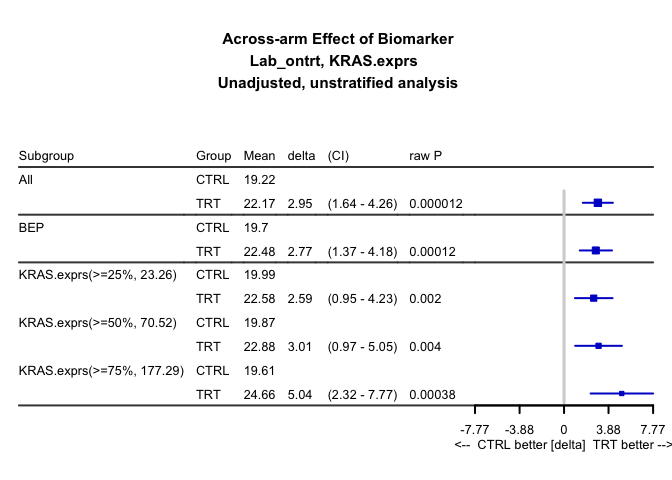

```r
res.multicut <- PlotTabForestBiomarker(data=input,
                                  outcome.class="continuous",
                                  outcome.var="Lab_ontrt",
                                  trt="Arm",
                                  var="KRAS.exprs",
                                  var.class="numeric",
                                  percentile.cutoff=c(.25,.5,.75),
                                  greater=TRUE, less=FALSE,
                                  show.itt=TRUE, show.bep=TRUE)
```

The forest plot above shows the difference in mean between treatment arm and control arm.

Function can also be used for continuous endpoint:

```
## some NA in var column, will ignore NA entries
```

[figure not shown]

```r
stepp.out <- PlotSTEPP(data = input,
          outcome.var = "Lab_ontrt",
          outcome.class = "continuous",
          trt = "Arm",
          var = "KRAS.exprs",
          placebo.code = "CTRL",
          active.code = "TRT"
)
```

## 4.6 Longitudinal analysis (e.g. PD biomarker)

### 4.6.1 Longitudinal Sample Data (`longbmkr`)

```r
head(longbmkr)
```

```
## # A tibble: 6 x 8
##     pid    trt    sex     age   edu     bmkr    vm       ep
##   <int> <fctr> <fctr>   <dbl> <dbl>    <dbl> <dbl>    <dbl>
## 1     1      1      f 23.1662    12 2.463927     0 198.2129
## 2     1      1      f 23.1662    12 2.463927     6 191.1682
## 3     1      1      f 23.1662    12 2.463927    18 270.6377
## 4     1      1      f 23.1662    12 2.463927    24 281.2230
## 5     1      1      f 23.1662    12 2.463927    42 311.6191
## 6     1      1      f 23.1662    12 2.463927    48 328.8269
```

Longitudinal Biomarker Sample Data

| Column Name | English Name | Description |
| --- | --- | --- |
| pid | PatientID | Unique Patient Identifier |
| trt | Treatment | Binary Classification of Treatment (1) or Control (0) |
| sex | Sex | Male (“m”) or Female (“f”) binary classification of sex |
| age | Age | Age of Patient |
| edu | Education | Years of Education for the Patient |
| bmkr | Biomarker Measurement | Biomarker Measurement\|Mock Biomarker Measurement Reading |
| vm | Visitation Month | Timepoint that data was collected |
| ep | Endpoint Measurement | Mock Endpoint Measurement Reading |

### 4.6.2 Baseline Plots of Subsetted Longitudinal Data

The baseline data for longitudinal data can be accessed by subsetting the data for only the visitation that took place at month 0. This can be done in a couple ways. In base-R (without any extra packages), this can be done by slicing the data on the condition.

```r
baseline_data <- longbmkr[longbmkr['vm'] == 0,]

kable(
    head(baseline_data),
    caption = 'longitudinal data subset by visit month to produce baseline data'
)
```

longitudinal data subset by visit month to produce baseline data

| pid | trt | sex | age | edu | bmkr | vm | ep |
| --- | --- | --- | --- | --- | --- | --- | --- |
| 1 | 1 | f | 23.16620 | 12 | 2.4639265 | 0 | 198.2129 |
| 3 | 0 | m | 29.44583 | 12 | 0.5459923 | 0 | 181.4341 |
| 6 | 1 | m | 75.33464 | 13 | 1.3735812 | 0 | 195.3713 |
| 7 | 1 | m | 38.86160 | 13 | 0.9065660 | 0 | 171.8755 |
| 8 | 0 | m | 60.37873 | 9 | 0.9683419 | 0 | 223.9027 |
| 9 | 1 | f | 24.14460 | 10 | 0.7958203 | 0 | 201.9100 |

Baseline data from longitudinal data can be used for any of the plots described herein similar to the examples above.

### 4.6.3 Longitudinal Plots with `PlotLong`

The `PlotLong` function is called with only a small set of arguments. The first is the data to plot and the second is an aesthetic mapping (using the function `aes()`) to map columns to visual outputs. In it’s most simple form, you can plot the distribution of endpoint readings over the timecourse, for the entire patient population. By default, the `PlotLong` function plots a line with points at the timepoints for which data exists with a ribbon showing the mean +/- standard error at that timestamp.

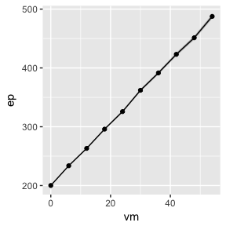

```r
PlotLong(longbmkr, x=vm, y=ep)
```

#### 4.6.3.1 Tukey Hinges and Whiskers

However, we may be more interested in the population distribution progression where we’d want to plot the Tukey boxplot hinges and whiskers over time. From this plot, we can see that although there is a slow rise in population mean, the patient response also becomes more distributed. You can specify, using the `fun.data` argument, exactly what the ribbons represent by using any keyword that can be passed to `stat_summary_funs` including “mean_sd” (mean +/- standard deviation), “mean_sd” (mean +/- standard error of the mean), “median_iqr” (median +/- interquartile range), “tukey” (tukey boxplot hinges and whiskers), “quartiles” and “deciles”.

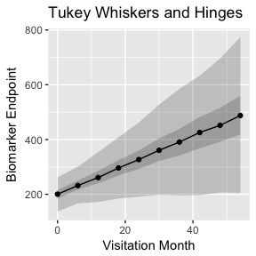

```r
PlotLong(longbmkr, x=vm, y=ep, fun.data = 'tukey',
         xlab = 'Visitation Month',
         ylab = 'Biomarker Endpoint',
         labs.title = 'Tukey Whiskers and Hinges')
```

#### 4.6.3.2 Plotting Subpopulations (Two-Armed Trials)

By giving aesthetic mappings to flags for subpopulations, you can easily vary the colors by adding aesthetics. In this case, we map the line color and ribbon fill to the treatment arm data, allowing a two arm trial representation.

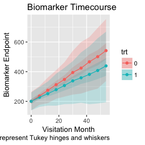

```r
PlotLong(longbmkr, x=vm, y=ep, color=trt, fill=trt,
         fun.data = 'tukey',
         xlab = 'Visitation Month',
         ylab = 'Biomarker Endpoint',
         labs.title = 'Biomarker Timecourse',
         labs.caption = 'Ribbons represent Tukey hinges and whiskers')
```

Similarly, we could also choose to subset our treatment arms by sex and represent this as two separate plots, one for each sex classification. In this case, we facet the plot by a formula (which is passed to `ggplot::facet_grid()`).

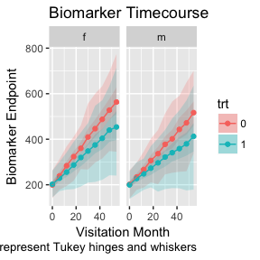

```r
PlotLong(longbmkr, x=vm, y=ep, group=trt, color=trt, fill=trt,
         fun.data = 'tukey', facet.fun = . ~ sex,
         xlab = 'Visitation Month',
         ylab = 'Biomarker Endpoint',
         labs.title = 'Biomarker Timecourse',
         labs.caption = 'Ribbons represent Tukey hinges and whiskers')
```

#### 4.6.3.3 Including sample counts

The `PlotLong` function also accepts inputs to the argument `show.counts`, accepting either “label” or “table”. This is used to represent sample number in each timepoint, for each grouping. For this and the followign plots, we’ll do some preprocessing for which we’ll use the `dplyr` package.

```r
library(dplyr)
```

[figure not shown]

```r
cutoff = 1.5

longbmkr %>%
    filter(vm <= 24) %>%
    mutate(bmkr = ifelse(bmkr > cutoff, 'Positive', 'Negative')) %>%
    mutate(trt  = ifelse(trt == 0, 'CTRL', 'TRT')) %>%

    PlotLong(x=vm, y=ep, color=trt, fill=trt, linetype=bmkr,
             fun.data = 'mean_se',
             show.counts = 'table',
             plot.style = 'errorbars',
             errorbar.linetype = 1,
             xlab = 'Visitation Month',
             ylab = 'Endpoint',
             labs.title = 'Biomarker Timecourse',
             labs.caption = '*ribbons represent mean value +/- standard error of the mean.')
```

#### 4.6.3.4 Specifying a function for adjustment

(Currently a work-in-progress!)

[figure not shown]

```r
cutoff = 1.5

longbmkr %>%
    filter(vm <= 24) %>%
    mutate(bmkr = ifelse(bmkr > cutoff, 'Positive', 'Negative')) %>%
    mutate(trt  = ifelse(trt == 0, 'CTRL', 'TRT')) %>%

    PlotLong(x=vm, y=ep, color=trt, fill=trt, linetype=bmkr,
             model = lm,
             model.formula = ep ~ sex + edu + age,
             fun.data = 'mean_se',
             show.counts = 'table',
             plot.style = 'errorbars',
             errorbar.linetype = 1,
             xlab = 'Visitation Month',
             ylab = 'Endpoint',
             labs.title = 'Biomarker Timecourse',
             labs.caption = '*ribbons represent mean value +/- standard error of the mean.')
```

# 5 Acknowledgement

We would like to thank Imola Fodor, Jane Zhenya Fridlyand and Zhuoye Xu for sponsoring this project. We would also like to thank to all previous developers of this project (Ru-Fang Yeh, Yuanyuan Xiao, YJ Choi, Ron Yu, Yuda Zhu, Jayantha Ratnayake, Sofia Mosesova, Chris Cabansk, Sydney Lee, Yi Li), including current ad-hoc advisors/contributors Wei Zou, Ray Lin and Guiyuan Lei.